IE582 HW1 EMRE GÖKÇE 2018702042

In this homework I used r Markdown and SQL database. I make some sections Hidden. In RMD file details can be displayed

r1(Hidden): In the first step csv tables were read and tables are registered with their spreadshit names.

r2(Hidden): This part involves the packages that I will use in the homework.

r3(Hidden): odbcConnect function reach my database named “IE582_Hw1”. And I will be reaching the database with “myConn” name

Querries below send the tables above(csv tables) to SQL. My database will also have these tables anymore

r4: By using Select querry I created premierleague data frame. It includes 320 match. To how the template I will be displaying first 10 rows of the frame.

```r
#TASK1

#premier league matches are selected as data.frame
premierleague <- sqlQuery(myConn,"select * From matches m Where m.league_id=148  ")
premierleague <- as.data.frame((premierleague))

premierleague[1:10,1:5] #representing first 10 rows to show the template - Total 320 Rows
```

```
##    match_awayteam_id match_hometeam_id match_id      epoch match_status
## 1               2627              2616   140194 1540035000     Finished
## 2               2613              2630   140198 1540044000     Finished
## 3               2614              2615   140195 1540044000     Finished
## 4               2623              2646   140200 1540044000     Finished
## 5               2628              2620   140199 1540044000     Finished
## 6               2629              2626   140197 1540044000     Finished
## 7               2619              2612   141486 1540134000     Finished
## 8               2611              2617   142626 1540234800     Finished
## 9               2632              2641   142767 1540320300     Finished
## 10              2630              2614   143407 1540648800     Finished
```

ANSWER OF TASK 1.1 a. Home Score(goals) b. Away Score(goals) c. Home Score(goals)– Away Score(goals)

(r pressure1):First histogram shows correspond a, Second histgram b and third one c.

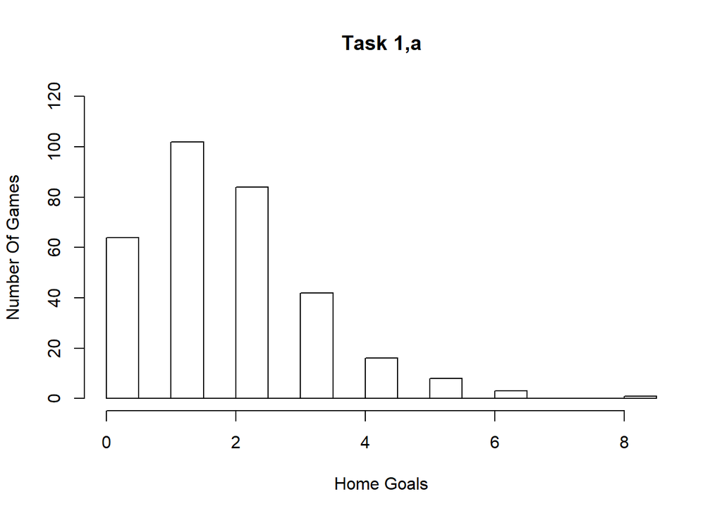

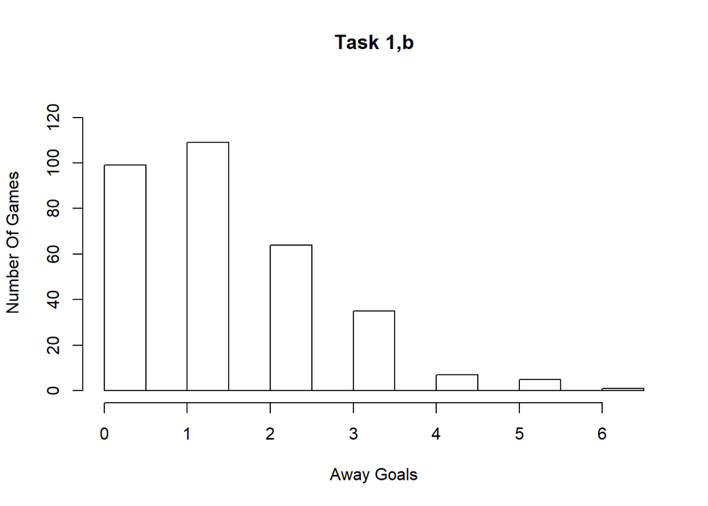

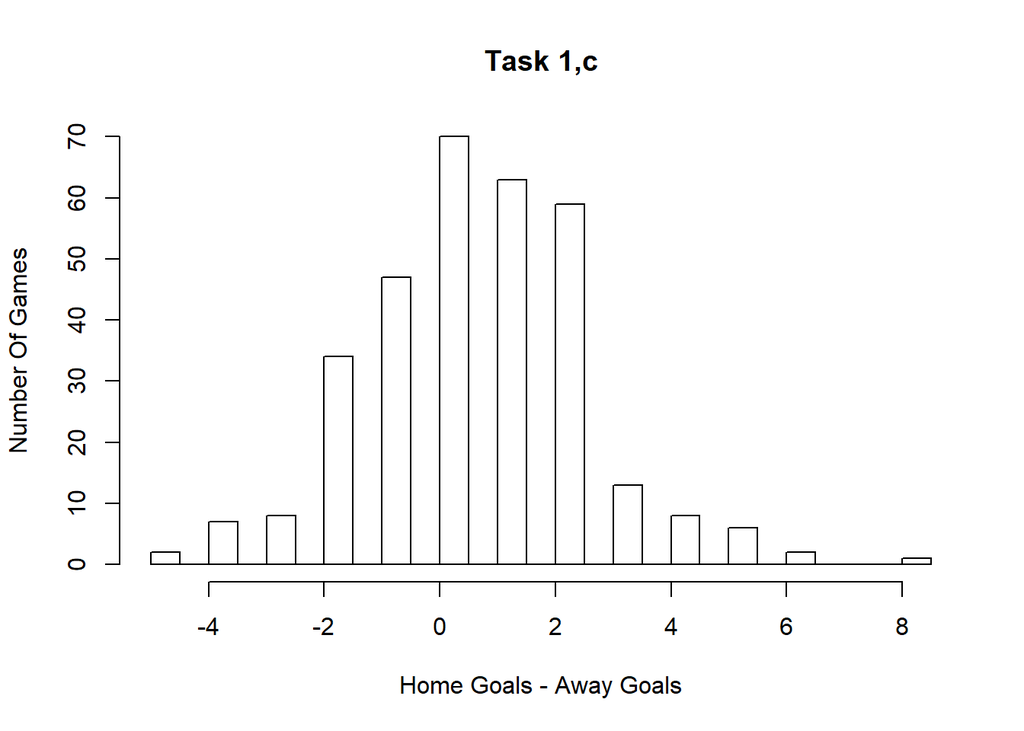

ANSWER OF TASK 1.2

(r pressure 2): Figures below show that the distribution fit to Poisson distribution.Blue line corresponds to expectation of related bins under the assumption of Poisson distribution

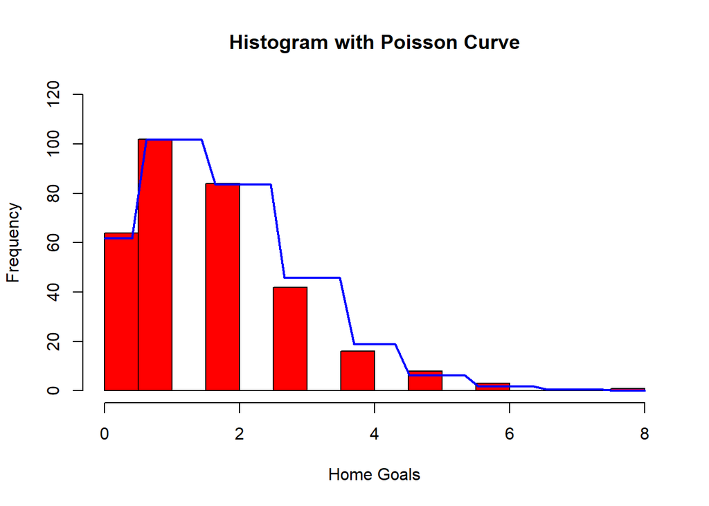

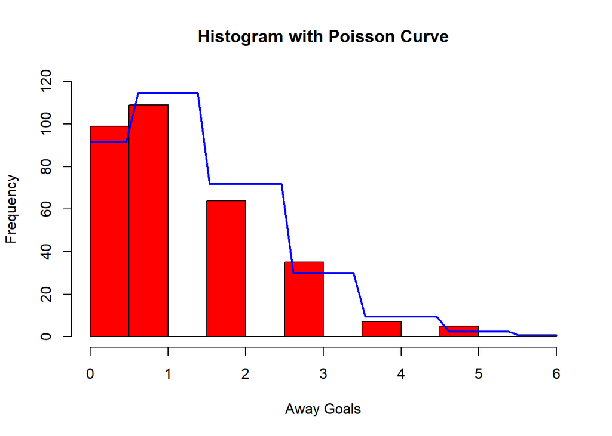

TASK 2

r5(Hidden):In the first part I filter the data of 4 bookmakers which are Interwetten.es,Titanbet,ComeOn and Jetbull

```
## character(0)
```

```r
FourBookMakers <- sqlQuery(myConn,"SELECT [match_id]
      ,[odd_bookmakers]
      ,[variable]
      ,MAX([value]) as value
  FROM [FourBookMakers_RawData]
  GROUP BY [match_id] ,[odd_bookmakers] ,[variable]")

FourBookMakers[1:10,] # top 10 of 16350 is shown.
```

```
##    match_id odd_bookmakers variable value
## 1    150842         ComeOn    odd_1  1.39
## 2    150842         ComeOn    odd_2  8.50
## 3    150842         ComeOn    odd_x  5.00
## 4    150842 Interwetten.es    odd_1  1.45
## 5    150842 Interwetten.es    odd_2  7.00
## 6    150842 Interwetten.es    odd_x  4.50
## 7    150842        Jetbull    odd_1  1.38
## 8    150842        Jetbull    odd_2  8.00
## 9    150842        Jetbull    odd_x  5.00
## 10   150842       Titanbet    odd_1  1.36
```

r7: The query performs pivotting. FourBookmakers have 1 bet for each row. The querry brings three value (odd_1,odd_2,odd_x) to the same row.

```r
#this querry pivots the variable creates table with columns of match_id , odd_1,odd_2,odd_x
#Prob_odd columns correspond the answer of Task 2.1
#Norm_odd columns correspond the answer of Task 2.2
match_detail_Raw <-
sqlQuery(myConn,"Select fbm.match_id,
       fbm.odd_bookmakers,
       m.result,
       fbm.value AS odd_1,
       (Select value
        FROM FourBookMakers_RawData fbm2
        WHERE fbm2.match_id = fbm.match_id AND fbm2.odd_bookmakers = fbm.odd_bookmakers AND fbm2.variable = 'odd_2') AS odd_2,
       (Select value
        FROM FourBookMakers_RawData fbm3
        WHERE fbm3.match_id = fbm.match_id AND fbm3.odd_bookmakers = fbm.odd_bookmakers AND fbm3.variable = 'odd_x') AS odd_x
from FourBookMakers_RawData fbm
INNER JOIN
(Select m.match_id AS match_id,
(CASE WHEN m.match_hometeam_score - m.match_awayteam_score > 0 THEN 1
      WHEN m.match_hometeam_score - m.match_awayteam_score = 0 THEN 0
      ELSE 2 END) AS result,
      ISNULL(m.match_hometeam_extra_score,0) AS HomeExtraScore,
      ISNULL(m.match_awayteam_extra_score,0) AS AwayExtraScore
From Matches m
Where m.league_id = 148) m ON fbm.match_id = m.match_id AND fbm.variable = 'odd_1'")
match_detail_Raw[1:8,]  #Total 1076 Rows
```

```
##   match_id odd_bookmakers result odd_1 odd_2 odd_x
## 1   150842 Interwetten.es      0  1.45  7.00  4.50
## 2   150842       Titanbet      0  1.36  8.50  5.25
## 3   150842         ComeOn      0  1.39  8.50  5.00
## 4   150842        Jetbull      0  1.38  8.00  5.00
## 5   150843 Interwetten.es      0  1.50  6.50  4.30
## 6   150843       Titanbet      0  1.62  5.50  4.20
## 7   150843         ComeOn      0  1.63  5.75  4.15
## 8   150843        Jetbull      0  1.63  5.00  3.80
```

ANSWER 2.1 & 2.2

r8: 1,Calculate the P(home win), P(tie) and P(away win) by P(x) = 1/odd. These probabilities are calculated as Prob_odd1,Prob_odd2 and Prob_oddx

These two kind probabilities are loaded to match_detail data frame. I will be displaying first 50 rows

```r
#2.1 and 2.2 cont
#Normalized probabilities and Probablities are calculated
#Calculation details are as follows:
match_detail <- cbind(match_detail_Raw,
             Norm_odd1 = match_detail_Raw$odd_1 /
               (match_detail_Raw$odd_1+match_detail_Raw$odd_2+match_detail_Raw$odd_x),
             Norm_odd2 = match_detail_Raw$odd_2 /
               (match_detail_Raw$odd_1+match_detail_Raw$odd_2+match_detail_Raw$odd_x),
             Norm_oddx = match_detail_Raw$odd_x /
               (match_detail_Raw$odd_1+match_detail_Raw$odd_2+match_detail_Raw$odd_x),
             Prob_odd1 = 1/match_detail_Raw$odd_1,
             Prob_odd2 = 1/match_detail_Raw$odd_2,
             Prob_oddx = 1/match_detail_Raw$odd_x,
             dif = 1/match_detail_Raw$odd_1-1/match_detail_Raw$odd_2)
sqlQuery(myConn,"IF EXISTS(SELECT *  FROM   match_detail)  DROP TABLE match_detail")
```

```
## character(0)
```

```r
sqlSave(myConn,match_detail,tablename = "match_detail",rownames = F)
match_detail[1:50,c(1,2,7,8,9,10,11,12)]  #Total 1076 Rows
```

```
##    match_id odd_bookmakers  Norm_odd1  Norm_odd2 Norm_oddx  Prob_odd1
## 1    150842 Interwetten.es 0.11196911 0.54054054 0.3474903 0.68965517
## 2    150842       Titanbet 0.09000662 0.56254136 0.3474520 0.73529412
## 3    150842         ComeOn 0.09335124 0.57085292 0.3357958 0.71942446
## 4    150842        Jetbull 0.09596662 0.55632823 0.3477051 0.72463768
## 5    150843 Interwetten.es 0.12195122 0.52845528 0.3495935 0.66666667
## 6    150843       Titanbet 0.14310954 0.48586572 0.3710247 0.61728395
## 7    150843         ComeOn 0.14137034 0.49869905 0.3599306 0.61349693
## 8    150843        Jetbull 0.15627996 0.47938639 0.3643337 0.61349693
## 9    150844 Interwetten.es 0.11462451 0.50592885 0.3794466 0.68965517
## 10   150844       Titanbet 0.09722222 0.55555556 0.3472222 0.71428571
## 11   150844         ComeOn 0.09001314 0.55847569 0.3515112 0.72992701
## 12   150844        Jetbull 0.09470752 0.55710306 0.3481894 0.73529412
## 13   154513 Interwetten.es 0.35260116 0.28323699 0.3641618 0.32786885
## 14   154513       Titanbet 0.35838150 0.28323699 0.3583815 0.32258065
```

[output cut: 87 more lines]

r9: “dif” column in match_detail keeps P(home) - P(away) information. I created 10 bins for this range and add Interval infromation to match_detail_Interval data frame. First 50 rows are displayed.

```r
#2.3
#Intervals are added to match_detail
#Interval columns show the intervals from 1 to 10. Interval(0.8,1) corresponds to 10, Interval(-1,-0.8) corresponds to to 1
match_detail_Interval <-
  sqlQuery(myConn,"SELECT m.*
           ,CASE WHEN dif < -0.8 THEN 1
           WHEN dif < -0.6 THEN 2
           WHEN dif < -0.4 THEN 3
           WHEN dif < -0.2 THEN 4
           WHEN dif <  0   THEN 5
           WHEN dif <  0.2 THEN 6
           WHEN dif <  0.4 THEN 7
           WHEN dif <  0.6 THEN 8
           WHEN dif <  0.8 THEN 9
           ELSE 10  END AS Interval
           FROM [match_detail] m")
sqlQuery(myConn,"IF EXISTS(SELECT *  FROM   match_detail_Interval)  DROP TABLE match_detail_Interval")
```

```
## character(0)
```

```r
sqlSave(myConn,match_detail_Interval,tablename = "match_detail_Interval",rownames = F)
match_detail_Interval[1:50,] #representing first 50 rows to show the template  Total 1076 Rows
```

```
##    match_id odd_bookmakers result odd_1 odd_2 odd_x  Norm_odd1  Norm_odd2
## 1    150842 Interwetten.es      0  1.45  7.00  4.50 0.11196911 0.54054054
## 2    150842       Titanbet      0  1.36  8.50  5.25 0.09000662 0.56254136
## 3    150842         ComeOn      0  1.39  8.50  5.00 0.09335124 0.57085292
## 4    150842        Jetbull      0  1.38  8.00  5.00 0.09596662 0.55632823
## 5    150843 Interwetten.es      0  1.50  6.50  4.30 0.12195122 0.52845528
## 6    150843       Titanbet      0  1.62  5.50  4.20 0.14310954 0.48586572
## 7    150843         ComeOn      0  1.63  5.75  4.15 0.14137034 0.49869905
## 8    150843        Jetbull      0  1.63  5.00  3.80 0.15627996 0.47938639
## 9    150844 Interwetten.es      1  1.45  6.40  4.80 0.11462451 0.50592885
## 10   150844       Titanbet      1  1.40  8.00  5.00 0.09722222 0.55555556
## 11   150844         ComeOn      1  1.37  8.50  5.35 0.09001314 0.55847569
## 12   150844        Jetbull      1  1.36  8.00  5.00 0.09470752 0.55710306
## 13   154513 Interwetten.es      0  3.05  2.45  3.15 0.35260116 0.28323699
## 14   154513       Titanbet      0  3.10  2.45  3.10 0.35838150 0.28323699
```

[output cut: 87 more lines]

r10: This data frame keep actual probabilities. The query calculates total number of matches and number of tie matches to the related bin. For example in the first bin there is no tie game from 7 match.

```r
#2.3
#the querry calculates average probability and actual probability
#Actual Probability is calculated by Draw/Total Match
stat1 <- sqlQuery(myConn,"Select m1.Interval,
       m1.Count AS TotalMatch,
       ISNULL(m2.Count,0) AS Draw
FROM
    (SELECT Interval,
           COUNT(Interval) AS Count
    FROM match_detail_Interval
    GROUP BY Interval) m1
LEFT JOIN
    (SELECT Interval,
           COUNT(Interval) As Count
    FROM match_detail_Interval m1
    Where result = 0
    GROUP BY Interval) m2
ON m1.Interval = m2.Interval
Order By Interval
")

stat1 <- cbind(stat1,ActProb = stat1$Draw/stat1$TotalMatch)
sqlQuery(myConn,"IF EXISTS(SELECT *  FROM   stat1)  DROP TABLE stat1")
```

```
## character(0)
```

```r
sqlSave(myConn,stat1,tablename = "stat1",rownames = F)
stat1
```

```
##    Interval TotalMatch Draw    ActProb
## 1         1          7    0 0.00000000
## 2         2         70    3 0.04285714
## 3         3         46    6 0.13043478
## 4         4        101   14 0.13861386
## 5         5        156   41 0.26282051
## 6         6        240   80 0.33333333
## 7         7        157   45 0.28662420
## 8         8        122   21 0.17213115
## 9         9        138   23 0.16666667
## 10       10         39    0 0.00000000
```

r11: This query do the same thing with query r10. Only difference this query have bookmaker detail.

```r
#the querry calculates average probability and actual probability for each odd_bookmaker
#calculation is sama as above
stat2 <- sqlQuery(myConn,"Select m1.Interval,
                  m1.odd_bookmakers,
                  m1.Count AS TotalMatch,
                  ISNULL(m2.Count,0) AS Draw
                  FROM
                  (SELECT Interval,
                    odd_bookmakers,
                    COUNT(Interval) AS Count
                    FROM match_detail_Interval
                    GROUP BY Interval,odd_bookmakers) m1
                  LEFT JOIN
                  (SELECT Interval,
                    odd_bookmakers,
                    COUNT(Interval) As Count
                    FROM match_detail_Interval m1
                    Where result = 0
                    GROUP BY Interval,m1.odd_bookmakers) m2
                  ON m1.Interval = m2.Interval AND m1.odd_bookmakers = m2.odd_bookmakers
                  Order By odd_bookmakers,Interval")

stat2 <- cbind(stat2,ActProb = stat2$Draw/stat2$TotalMatch)
sqlQuery(myConn,"IF EXISTS(SELECT *  FROM   stat2)  DROP TABLE stat2")
```

```
## character(0)
```

```r
sqlSave(myConn,stat2,tablename = "stat2",rownames = F)
stat2
```

```
##    Interval odd_bookmakers TotalMatch Draw    ActProb
## 1         1         ComeOn          2    0 0.00000000
## 2         2         ComeOn         18    1 0.05555556
## 3         3         ComeOn         11    1 0.09090909
## 4         4         ComeOn         25    4 0.16000000
## 5         5         ComeOn         42   11 0.26190476
## 6         6         ComeOn         58   19 0.32758621
## 7         7         ComeOn         42   12 0.28571429
## 8         8         ComeOn         29    5 0.17241379
## 9         9         ComeOn         36    6 0.16666667
## 10       10         ComeOn         10    0 0.00000000
## 11        1 Interwetten.es          2    0 0.00000000
## 12        2 Interwetten.es         15    0 0.00000000
## 13        3 Interwetten.es         12    2 0.16666667
## 14        4 Interwetten.es         26    3 0.11538462
```

[output cut: 26 more lines]

r12: This query combines actual probabilities and average tie probabilities of bookmakers.Probability of bookmakers is not Normalized. It is average of 1/odd_x

```r
#2.3
#Average shows average of odd_bookmakers
CommanComparison <- sqlQuery(myConn,"Select s.Interval, s.ActProb, mdi.AVerage
FROM
(Select Interval, AVG(Prob_oddx) As Average
  From match_detail_Interval
  GROUP BY Interval) mdi
INNER JOIN
stat1 s
ON mdi.Interval = s.Interval")
CommanComparison
```

```
##    Interval    ActProb   AVerage
## 1         1 0.00000000 0.1152067
## 2         2 0.04285714 0.1704808
## 3         3 0.13043478 0.2373491
## 4         4 0.13861386 0.2723536
## 5         5 0.26282051 0.2986147
## 6         6 0.33333333 0.2989753
## 7         7 0.28662420 0.2818499
## 8         8 0.17213115 0.2278809
## 9         9 0.16666667 0.1752196
## 10       10 0.00000000 0.1157143
```

r13: Query have additionally bookmaker detail.

```r
#2.3
BookmakerComparison <- sqlQuery(myConn,"Select s.Interval, s.odd_bookmakers,  mdi.AVerage, s.ActProb
FROM
(Select Interval, AVG(Prob_oddx) As Average,odd_bookmakers
  From match_detail_Interval
  GROUP BY Interval,odd_bookmakers) mdi
INNER JOIN
stat2 s ON
 mdi.Interval = s.Interval AND mdi.odd_bookmakers = s.odd_bookmakers
 ORDER BY odd_bookmakers,Interval")
BookmakerComparison
```

```
##    Interval odd_bookmakers   AVerage    ActProb
## 1         1         ComeOn 0.1143791 0.00000000
## 2         2         ComeOn 0.1653784 0.05555556
## 3         3         ComeOn 0.2363526 0.09090909
## 4         4         ComeOn 0.2688029 0.16000000
## 5         5         ComeOn 0.2964851 0.26190476
## 6         6         ComeOn 0.2983211 0.32758621
## 7         7         ComeOn 0.2812532 0.28571429
## 8         8         ComeOn 0.2274045 0.17241379
## 9         9         ComeOn 0.1731065 0.16666667
## 10       10         ComeOn 0.1120509 0.00000000
## 11        1 Interwetten.es 0.1156417 0.00000000
## 12        2 Interwetten.es 0.1710600 0.00000000
## 13        3 Interwetten.es 0.2325589 0.16666667
## 14        4 Interwetten.es 0.2741426 0.11538462
```

[output cut: 26 more lines]

ANSWER OF TASK 2.3

Since blue line is average of gray points they follow similar patterns. The difference come from the phase difference.For example, when x=2, it shows average from P(home)-P(away) between (-0.8,-0.6). However gray points on x=2 are corresponding to -0.6. For this reason in the left tale blue line is below the gray points and in the right tale above. This comment is the case for all plot below so I am not going to repeat the same comment for all.

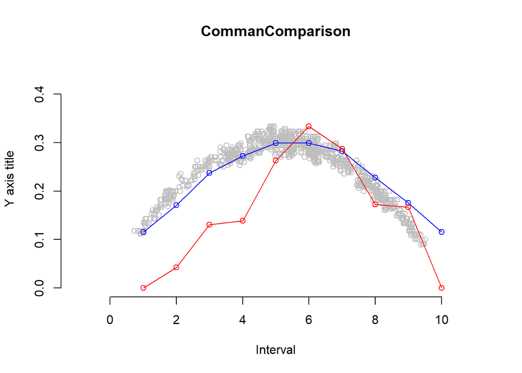

ANSWER OF 2.4

(r pressure4): I repeated same analysis for each bookmaker.For all bookmakers expectation of bin 6 is more than 1 like in the main picture. So although there are differences main picture is almost same all 4 bookmakers.

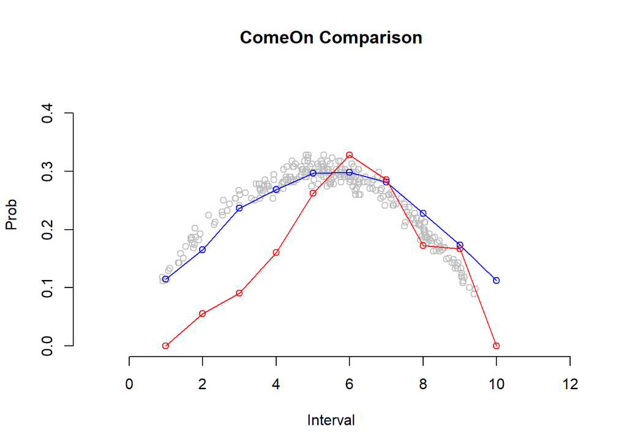

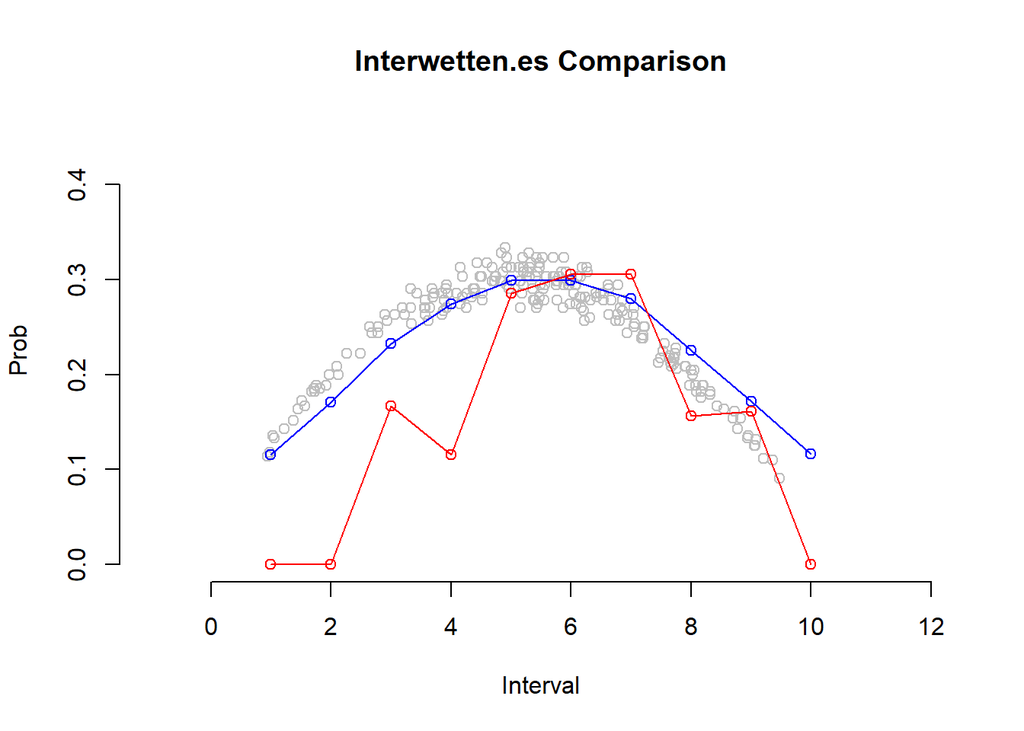

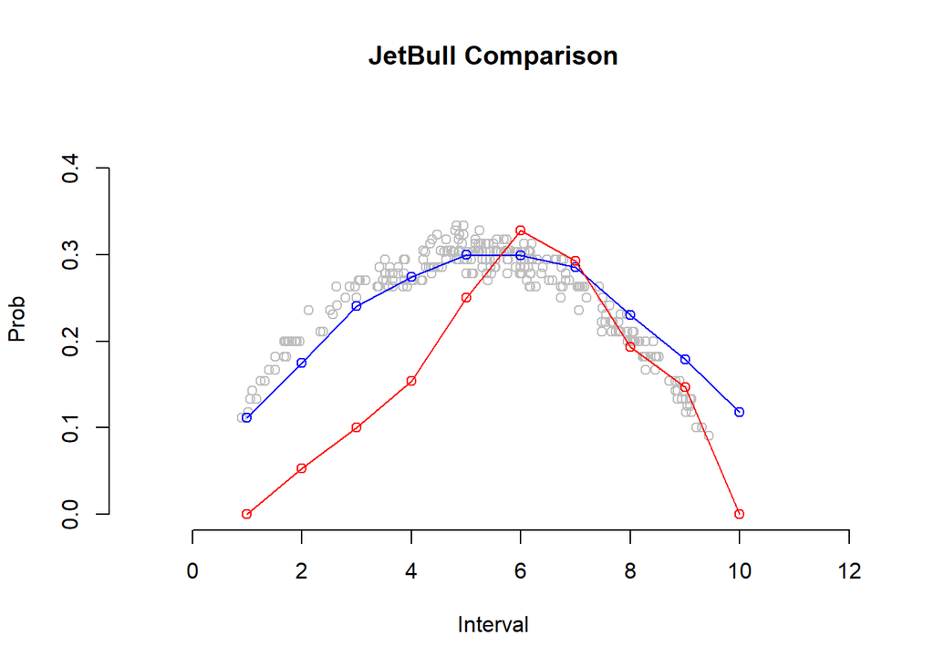

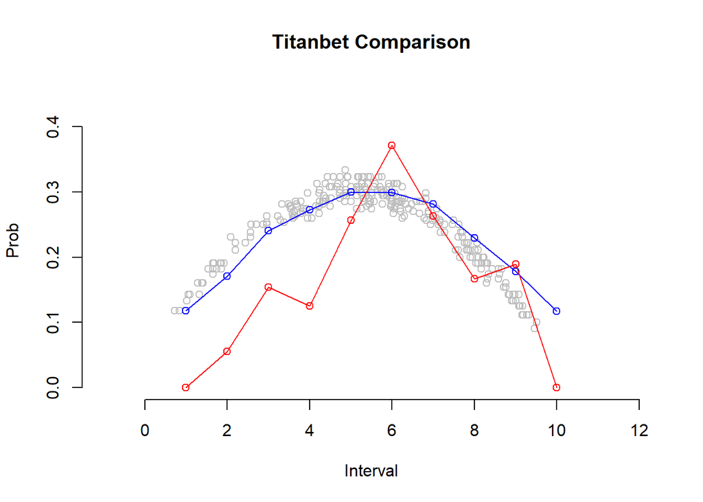

Task3